# Reproducible Research - Peer Assessment 1

This is r-markdown file for the peer assessment.

Loading some of the packages

```r
library(plyr)
```

```r
library(ggplot2)
library(dplyr)
```

reading the data and changing the data types:

```r
data1 <- read.csv('activity.csv',sep = ',',header=T,na.strings='?')
data1$steps <- as.numeric(as.character(data1$steps))
data1$date <- as.Date(data1$date,"%Y-%m-%d")
```

summarizing the data

total steps before without substituting NA

```r
total_with_na <- ddply(data1,.(date),summarize,steps_total=sum(steps),steps_mean=ceiling(mean(steps)))
head(total_with_na)
```

```
##         date steps_total steps_mean
## 1 2012-10-01          NA         NA
## 2 2012-10-02         126          1
## 3 2012-10-03       11352         40
## 4 2012-10-04       12116         43
## 5 2012-10-05       13294         47
## 6 2012-10-06       15420         54
```

plotting the histogram of total steps against date

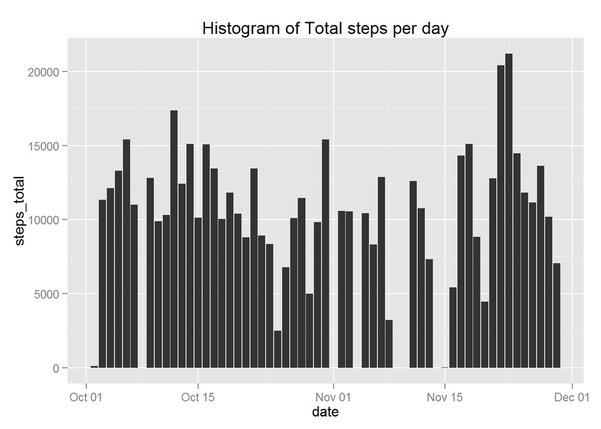

```r
fig1<-ggplot(total_with_na,aes(date,steps_total)) + geom_bar(stat = "identity",binwidth = .5) +
  labs(title = "Histogram of Total steps per day",xlab="Date",ylab="Total Steps")
print(fig1)
```

Calculating the mean and median

Mean of total number of steps per day

```r
mean(total_with_na$steps_total,na.rm=T)
```

```
## [1] 10766.19
```

Median of total number of steps per day

```r
median(total_with_na$steps_total,na.rm=T)
```

```
## [1] 10765
```

Average daily activity plan

Calculating the steps mean by interval

```r
steps_mean_by_interval <- ddply(data1,.(interval),summarize,steps_total=sum(steps,na.rm=TRUE),steps_mean=ceiling(mean(steps,na.rm=TRUE)))
head(steps_mean_by_interval,3)
```

```
##   interval steps_total steps_mean
## 1        0          91          2
## 2        5          18          1
## 3       10           7          1
```

Plotting the Daily activity plan

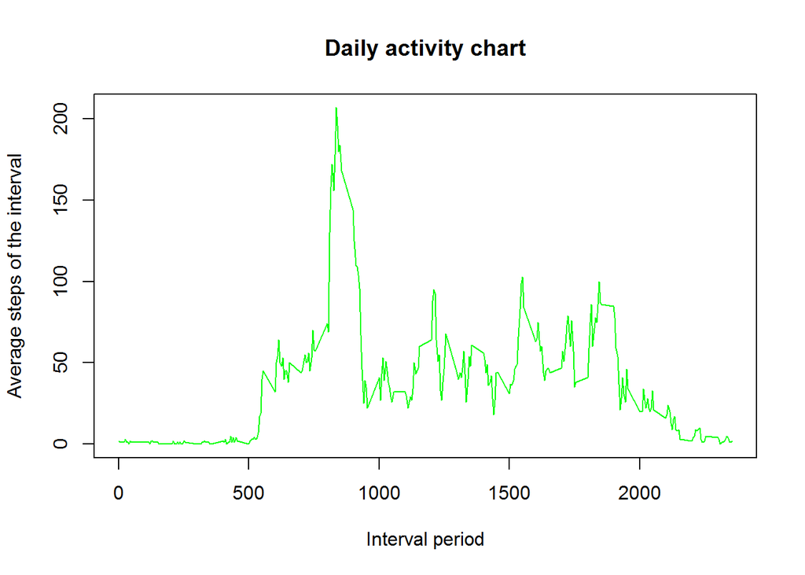

```r
with(steps_mean_by_interval,plot(interval,steps_mean,type='l',col='green',xlab="Interval period",ylab="Average steps of the interval",main="Daily activity chart"))
```

The interval at which most steps are recorded

```r
d2<-max(steps_mean_by_interval$steps_mean)
index <- steps_mean_by_interval$steps_mean %in% d2
maxinterval <- steps_mean_by_interval[index, ]
maxinterval
```

```
##     interval steps_total steps_mean
## 104      835       10927        207
```

Total Number of missing values

```r
sum(!complete.cases(data1))
```

```
## [1] 2304
```

Imputing the missing values with the mean of that interval

```r
impute.data<- join(data1,steps_mean_by_interval,by="interval")
impute.data$steps <- with(impute.data,ifelse(is.na(steps)==TRUE,steps_mean,steps))
```

All the data has been replaced

```r
sum(!complete.cases(impute.data))
```

```
## [1] 0
```

plotting the histogram of total steps against date after imputing the missing values

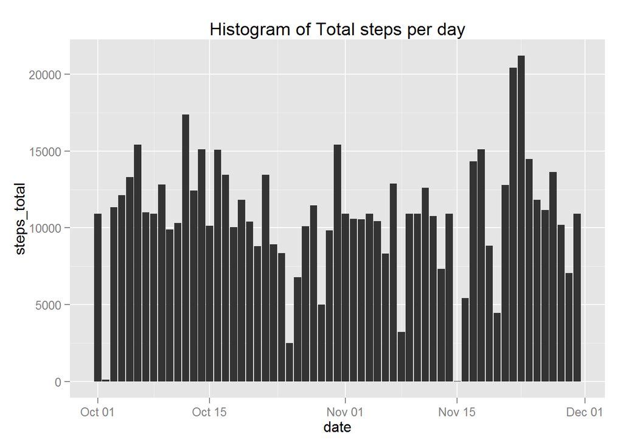

```r
total_without_na <- ddply(impute.data,.(date),summarize,steps_total=sum(steps),steps_mean=ceiling(mean(steps)))
fig2<-ggplot(total_without_na,aes(date,steps_total)) + geom_bar(stat = "identity",binwidth = .5) +
  labs(title = "Histogram of Total steps per day",xlab="Date",ylab="Total Steps")
print(fig2)
```

Calculating the mean and median of Imputed data

Mean of total number of steps per day

```r
mean(total_without_na$steps_total,na.rm=T)
```

```
## [1] 10784.92
```

Median of total number of steps per day

```r
median(total_without_na$steps_total,na.rm=T)
```

```
## [1] 10909
```

Finding the activity pattern between weekdays and weekends

Factoring the dates into weekdays and weekends

```r
impute.data1 <- impute.data
impute.data$weekdays <- factor(format(impute.data$date,"%A"))

levels(impute.data$weekdays) <- list(Weekday = c("Monday","Tuesday","Wednesday","Thursday","Friday"),
                                       Weekend=c("Saturday","Sunday"))

levels(impute.data$weekdays)
```

```
## [1] "Weekday" "Weekend"
```

```r
averages_by_weekdays <- aggregate(impute.data$steps, list(interval = as.numeric(as.character(impute.data$interval)),
                                                            weekdays = impute.data$weekdays),FUN = "mean")
names(averages_by_weekdays)[3] <- "steps_mean"
```

Plotting the activity pattern by weekdays and weekends

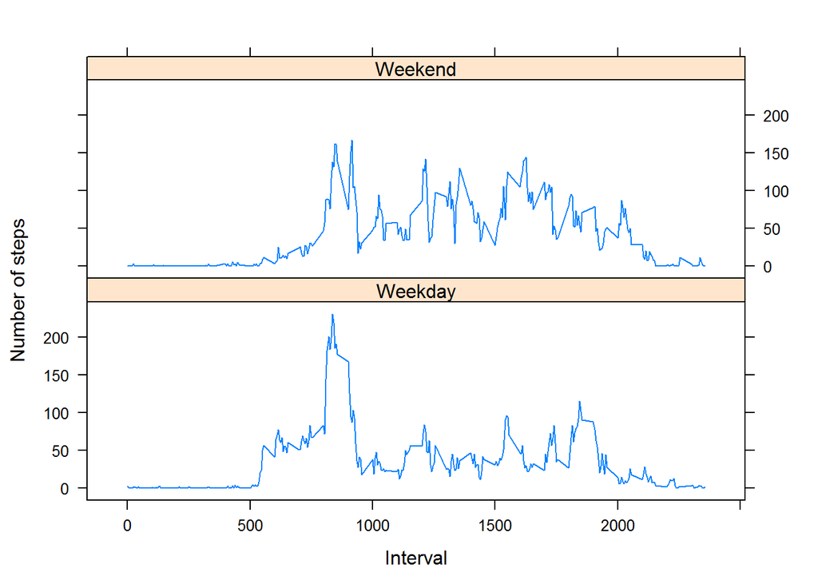

```r
library(lattice)
fig3 <- xyplot(averages_by_weekdays$steps_mean ~ averages_by_weekdays$interval | averages_by_weekdays$weekdays,
                 layout = c(1, 2), type = "l", xlab = "Interval", ylab = "Number of steps")
print(fig3)
```